# Final Draft

## Member Present

-**Zhan Yu**, Will Hu, WAI ZIN LINN

## Member Absent

-Martin Lozano

## *Introduction*

-Suicide is an act that unfortunately takes too many lives. According to World Health Organization, nearly 800000 people die of suicide every year, that is, one person dies every 40 seconds. Suicide is a global phenomenon throughout the whole life cycle. Effective, evidence-based interventions can be taken at the population, sub population and individual levels to prevent suicide and suicide attempts. There are indications that more than 20 of every adult who dies of suicide may attempt suicide. We chose to focus on suicide rate because it will be an interesting topic to explore and this topic contains a vast amount of data. We decided to narrow our focus down to some particular factors that can potentially influence suicide rate. We are curious about the relationship between suicide rate and GDP per capita of each country, gender, age groups, so we decided to explore data about the suicide rates in each age group and gender in each country. With all the data and graph, we can understand the factors influence suicide rates, so we can have the better way to reduce the suicide rate more effective in the future.

In this report, we plan to answer the question:

1.What is the relationship between different countries’ GDP per capita and their suicide rates?

2.What is the relationship between different genders and their suicide rates?

3.What is the relationship between different age groups and their suicide rates?

## *Background*

-This data set is pulled from four other datasets linked by time and space. These datasets come from United Nations Development Program, World Bank, World Health Organization, and Suicide in the Twenty-First Century.

-Dataset Link: https://www.kaggle.com/russellyates88/suicide-rates-overview-1985-to-2016[^1]

-There are many factors like age, country, gdp, and gender can influence the suicide rate, so we are going to investigate the relationship between these factors and suicide rate.

-We do have unusual factors, because we are missing about half of the countries in the world [^2] in our dataset like China, India, and many African countries, which have big population sizes and can affect our results. For example, the African countries can affect gdp per capita vs suicide rate linear regression model.

-For the rest of report, we intend to analyze the dataset and give graphs to visualize the data.

## *Analysis*

### Q1: The relationship between different countries’ GDP per capita and their suicide rates.

- This result is calculated by summing of suicides rate in 100k people of each country, and summing the capita GDP of each country. Then we use scatter plot to show the relationship between countries’ GDP per capita and the total suicide rate in 100k people of each country. -Evidence: The project presented on https://rpubs.com/beancounter/430586 shows the same result as ours.

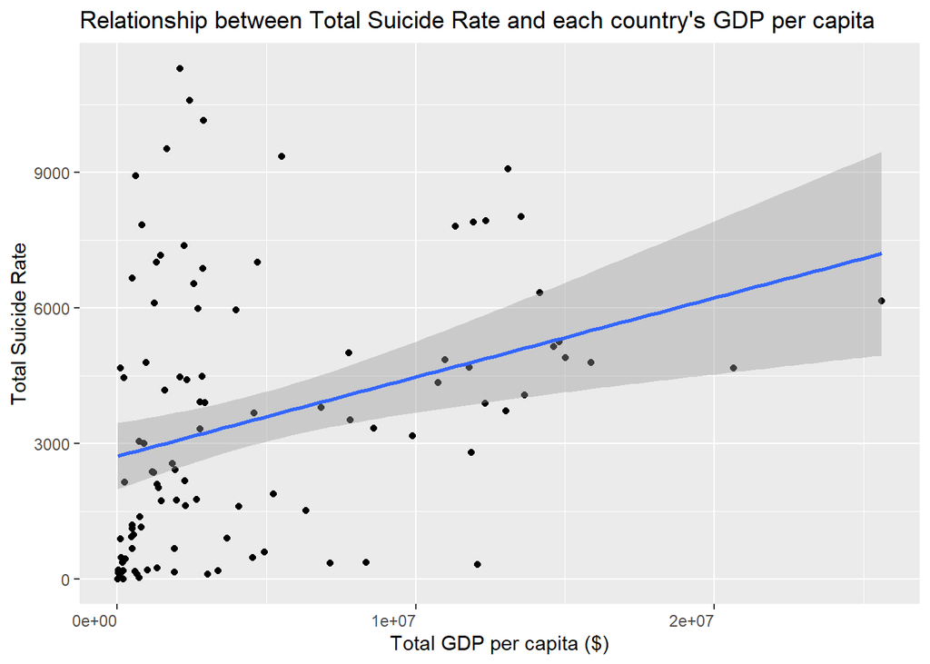

### Linear Regression Model Summary

The slope is 0.0001753973, and the correlation coefficient is 0.3175026, so with the increase of gdp per capita, the suicide rate will also increase.

Besides gdp per capita, another area we can explore is the relationship between age groups and their suicide rates, which is what we will do in the next section.

### Q2 The relationship between different age groups and their suicide rates.

| age | rows | suicide | total | avg_suicide_num |
| --- | --- | --- | --- | --- |
| 15-24 years | 4642 | 174.17966 | 1861901.5 | 0.0093549 |
| 25-34 years | 4642 | 242.11805 | 1817773.3 | 0.0133195 |
| 35-54 years | 4642 | 528.25097 | 3096916.9 | 0.0170573 |
| 5-14 years | 4610 | 11.33709 | 1821842.4 | 0.0006223 |
| 55-74 years | 4642 | 357.26907 | 1896433.7 | 0.0188390 |
| 75+ years | 4642 | 140.69754 | 573735.7 | 0.0245231 |

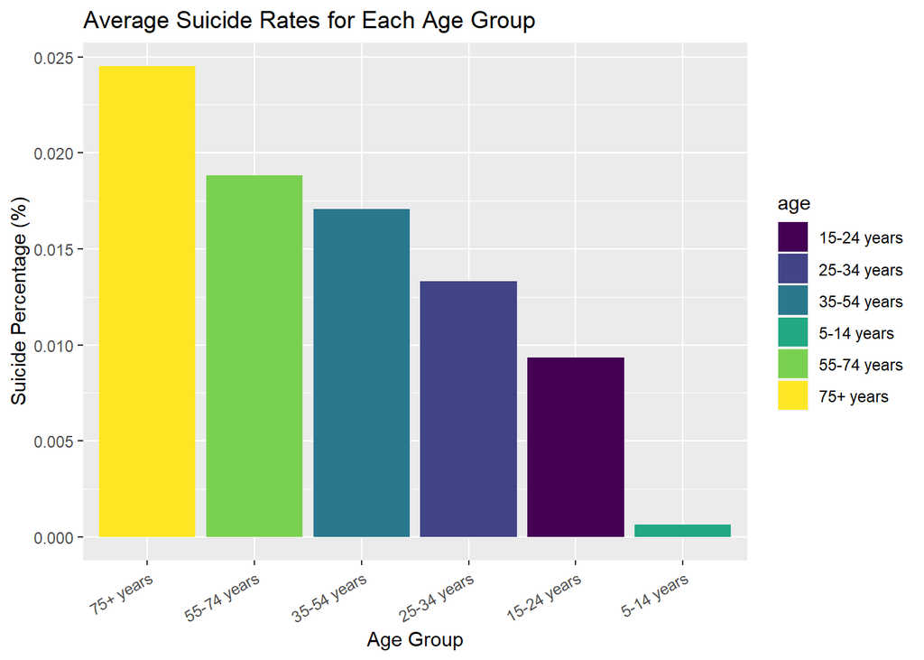

Besides age group, another area we can explore is the relationship between genders and their suicide rates, which is what we will do in the next section.

### Q3 The relationship between different genders and their suicide rates.

| sex | rows | suicide | total | avg_suicide_num |
| --- | --- | --- | --- | --- |
| Female | 13910 | 112.1143 | 1888769 | 0.0059358 |
| Male | 13910 | 373.0345 | 1800818 | 0.0207147 |

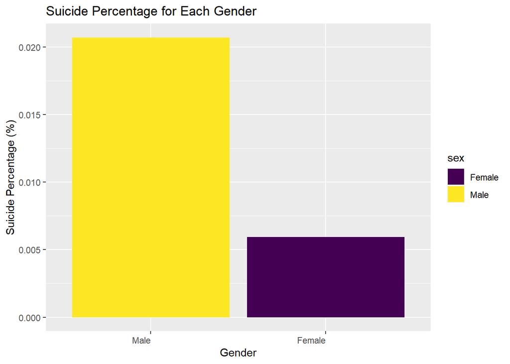

-Using hypothesis test on male percentage suicide rate.

| sex | rows | suicide | total | p |
| --- | --- | --- | --- | --- |
| male | 13910 | 373 | 1800818 | 0.0002071 |

## *Discussion*

### Potential short-comings

In the graph, comparing the relationship between age group and suicide rate, there seems to be some data missing for certain age groups of some years for some countries. For Albania’s 2015 suicide total number, all of the age group is 0. Therefore, some of the data may be missing or there is no suicide taking place in that year at Albania. The data also seems to skip out on some years. For example in Albania, the years 1990, 1991 are not present. Additionally, some major countries such as China and India, and many African countries are missing from the dataset, which could drastically change some of our graphs and findings. For example, the GDP versus suicide rate linear regression model could be altered drastically if more African countries were included.

### Potential future directions

For potential future directions, we have new questions: 1.What other factors may influence the suicide rate? (May need to look at different or larger datatsets). 2.For country with high suicide rates, what factor contributes that most? The comparison of different countries suicide rates can be calculated differently, as we took an approach which looks at the average suicide rate for each country, while we could also look at which country has the highest total suicides, instead of using the average. The same is applicable for the comparison with gender and GDP. The relationship between suicide rate and GDP could also be computed using GDP per year instead of GDP per capita, which we used.One important fact to collect to refine our understanding would be to see how these three organizations collected this data, to better understand if there was any inherent bias or any inherent flaws with the collection, to see if our data is skewed in any particular direction.

### Summary

[^1]: https://www.kaggle.com/russellyates88/suicide-rates-overview-1985-to-2016
[^2]: Afghanistan, Algeria, Andorra, Angola, Bangladesh, Benin, Burkina Faso, Bhutan, Bolivia, Botswana, Brunei, Burundi, Côte d’Ivoire, Cambodia, Cameroon, Central African Republic, Chad, China, Comoros, Congo, Djibouti, Egypt, Eritrea, Ethiopia, Equatorial Guinea, Egypt, Eswatini (Swaziland), Gabon, Gambia, Ghana, Guinea, Guinea-Bissau, Honduras, Haiti, Holy See, India, Indonesia, Iran, Iraq, Jordan, Kenya, Laos, Lebanon, Lesotho, Liberia, Libya, Liechtenstein, Malaysia, Madagascar, Morocco, Moldova, Mozambique, Myanmar, Monaco, Malawi, Mali, Marshall Islands, Mauritania, Micronesia, Monaco, Namibia, Nauru, Nepal, Netherlands, Niger, Nigeria, North Korea, North Macedonia,Pakistan, Palau, Peru, Papa New Guinea, Palestine State, Rwanda, Samoa, Sao Tome and Principe, Saudi Arabia, Senegal, Sierra Leone, Solomon Islands, Somalia, South Sudan, Sudan, Syria, Tanzania, Togo, Tongo, Tajikistan, Timor Leste, Tuvalu, Tunisia, Uganda, Tunisia, Vanuatu, Vietnam, Venezuela, Yemen, Zambia, Zimbabwe
[^3]: https://rpubs.com/beancounter/430586